# 518_Project

Josephat Oyondi, Hillary Kemei, Geoffrey Arumba

```r
#loading libraries
library("tidyverse")
```

```r
library("readxl")
library("dplyr")
library("patchwork") #allows visualization of more than one chart

library("stringr") #load library for searching string matches
 #reading data from the excel file
```

```r
#reading data from the excel file
my_data <- read_excel("Traffic_Capacity_AA.xls") #source - http://web.mit.edu/airlinedata/www/default.html
```

```r
#organize financial data in columns for easier analysis
organized_data <- my_data %>%
  pivot_longer(
    cols = `1995` : `2020`,
    names_to = 'Year',
    values_to = 'Finance_values', values_drop_na = TRUE)
```

```r
#create a function to extract the finance metric data
extract_finance_data <- function(string){
  organized_data[str_detect(organized_data$Abbrevs, string), ]
}
```

```r
#use the extract finance function to extract data for each financial metric
Air_expense_per <-  data.frame(extract_finance_data("A_Exp"))
pass_rev_per <- data.frame(extract_finance_data("PAX_Rev"))
total_expenses <- data.frame(extract_finance_data("SUM_Exp"))
total_pass_rev <- data.frame(extract_finance_data("SUM_PAX"))

asm <-  data.frame(extract_finance_data("SUM_ASM"))
```

```r
expenses <- select(Air_expense_per, Year, Financial_measures, Finance_values)
pax_rev <- select(pass_rev_per, Year, Financial_measures, Finance_values)
```

```r
#create a function for generating visuals ======================================

gen_visuals <- function(vis_data){
  #plot table
  year = as.numeric(vis_data$Year)
  ggplot(data = vis_data, aes(x = year,
                              y = Finance_values,
                              group = Financial_measures,
                              color = Financial_measures)) +
    geom_line();
}
#end of gen_visuals function ===================================================
#generate visualization for expenses
```

```r
#combine visualizations for revenue, expenses and profit

#find profit
profit <- pax_rev %>%
  mutate(profits = (pax_rev$Finance_values - expenses$Finance_values))

#changing row names to profit

profit$Financial_measures[which(profit$Financial_measures == "Pax Rev - Atlantic")]<- "Profit - Atlantic"
profit$Financial_measures[which(profit$Financial_measures == "Pax Rev - Domestic")]<- "Profits-Domestic"
profit$Financial_measures[which(profit$Financial_measures == "Pax Rev - International")]<- "Profits-International"
profit$Financial_measures[which(profit$Financial_measures == "Pax Rev - Latin America")]<- "Profits- Latin America"
profit$Financial_measures[which(profit$Financial_measures == "Pax Rev - Pacific")]<- "Profits-Pacific"
```

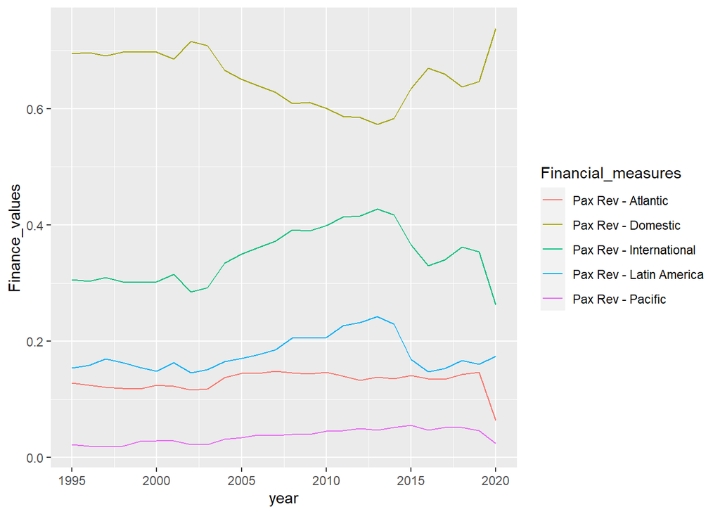

```r
gen_visuals(pax_rev)
```

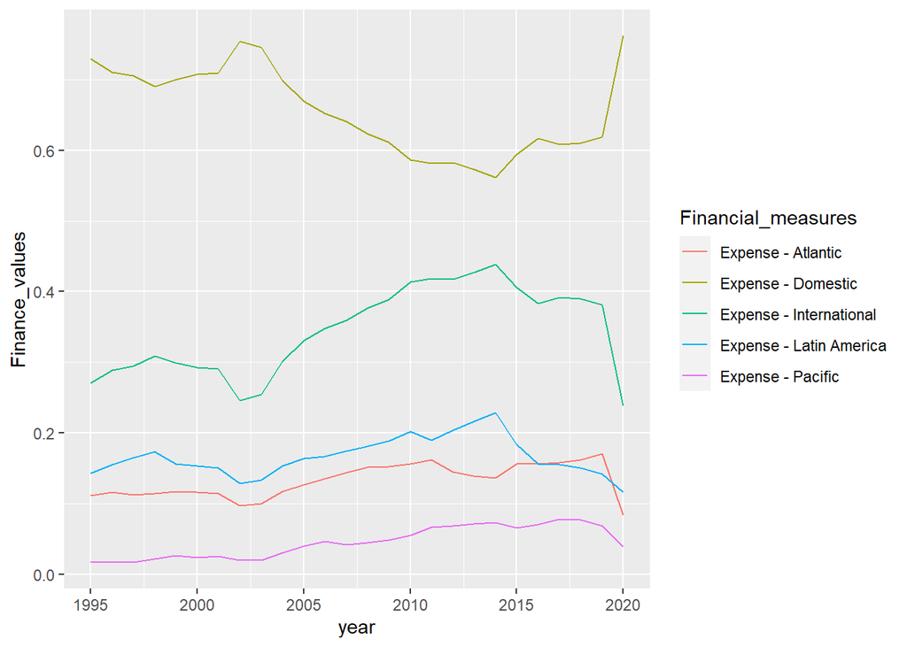

```r
gen_visuals(expenses)
```

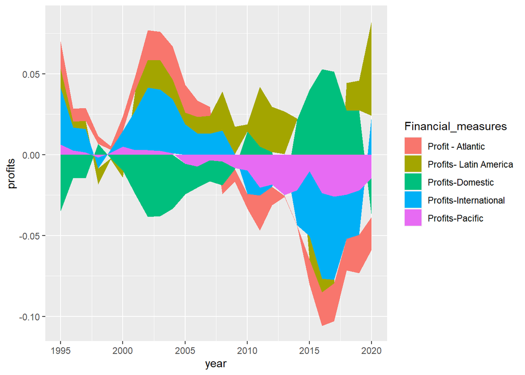

```r
#plot profit
year = as.numeric(profit$Year)
profit_plot <- ggplot(data = profit, aes(x = year,
                          y = profits,
                          fill = Financial_measures))+
  geom_area();

#combining add

profit_plot
```

To achieve objective 1 (To determine which of the operating regions has been profitable for America Airlines.) of our project, my analysis was based on the variations across all the years. This is because, although domestic flights recorded the highest revenue throughout all the years, the expenses were positively correlated with revenue, suggesting that the profits generated might be lower.

```r
expe_cummulatives <- expenses %>%
  group_by(Year) %>%
  summarise(exp_ = sum(Finance_values))


#####################################################

rev_cummulatives <- pax_rev %>%
  group_by(Year) %>%
  summarise(rev_ = sum(Finance_values))
```

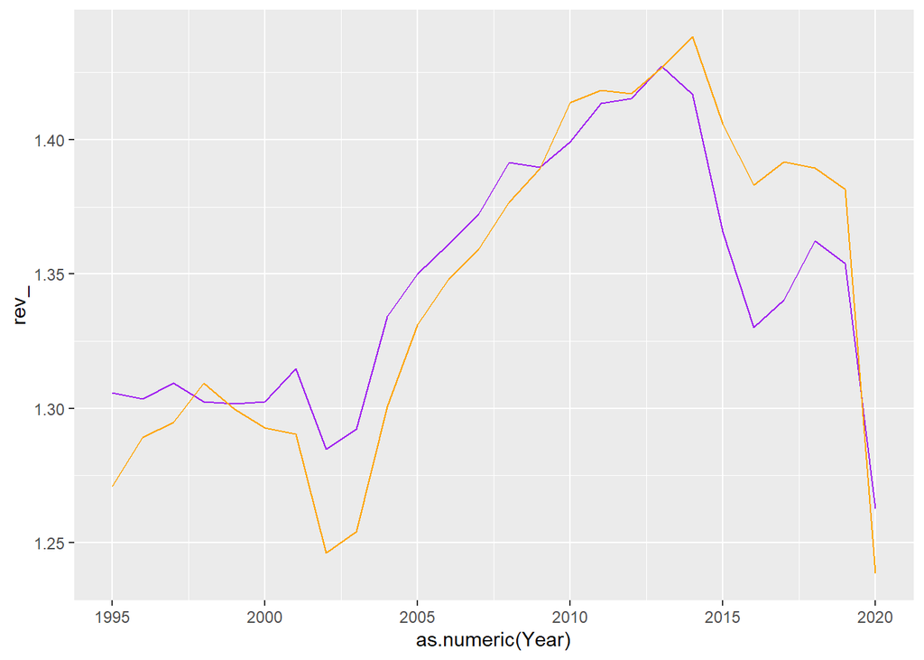

```r
#convert to dataframe
rev_data_f = data.frame(rev_cummulatives)
exp_data_f = data.frame(expe_cummulatives)

#create charts for revenue vs expenses throughout the period.
#plot chart with two data sets

compare_revexp <- ggplot(NULL) +
  geom_line(data = rev_data_f, aes(x = as.numeric(Year), y = rev_), col = "purple") +
  geom_line(data = exp_data_f, aes(x = as.numeric(Year), y = exp_), col = "orange")

compare_revexp
```

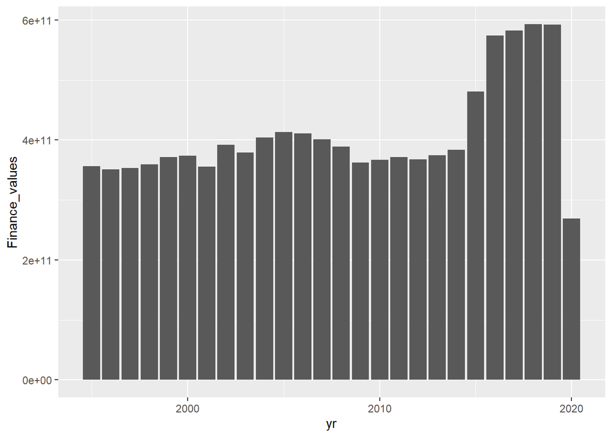

```r
#change Year to numeric
yr = as.numeric(asm$Year)
#bar
ggplot(asm, aes(yr, Finance_values)) + geom_col()
```

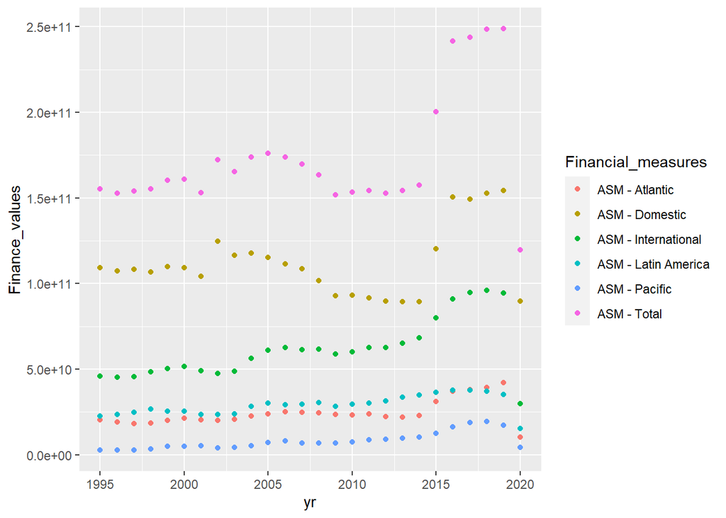

```r
##line
ggplot(asm, aes(x=yr, y=Finance_values, group = Financial_measures,
                color = Financial_measures)) + geom_point()
```

#The third task of this project was to establish the year in which American Airlines had the highest and lowest available passenger seats per region.To increase profits and leverage against other competitors, an airline has to operate on the economies of scale and for the airline industry, that means making more seats available.Looking casually at the raw data from American Airlines, it is not easy to establish which year the airline and its constituent operating regions had the highest number of available seats.To be able to achieve this, we visualized the ASM variable of the data.ASM is an acronyn for Available Seat Mile and it measures the total number of seats offered as opposed to the number of passengers onboard.From the visualized data, it is apparent that the lowest available seats were in 2020.There were also relatively lower available seats in 2001 and 2009 but not as more markedly as in 2020.This low availability of seats in 2020 can be solely attributed to the havoc that covid 19 racked on the global economy and particularly air travel.American Airlines had to scale down its operations due to reduced passenger availability and also because of the US and other governments closing of their airspaces to international flights and this led to the lower availability of seats.The lower availability of seats in 2009 is attributed to the global economic recession while the slump in 2001 brought out in the visualization charts above is solely attributed to the effects of the unprecedented terror attacks on the US.This costed the US Airline industry upto eight billion dollars in losses .sources: (https://www.cnbc.com/2021/09/11/how-9/11-forever-changed-air-travel.html),(https://citeseerx.ist.psu.edu/viewdoc/download?doi=10.1.1.203.1445&rep=rep1&type=pdf).